# NYPD Shooting Incidents Project Rmd

Jie Shen

2023-09-22

## Project goal

The project is to discover patterns and trends of shooting incidents in NY. For example, are there time of day, days of week, or months of year that has more incidents? Were there any improvement of NY shooting incidents over the past few years? Where are some high risk areas?

## Packages needed

Be sure the following packages are installed first:

- tidyverse
- ggplot2
- lubridate
- hms

## Load packages

```r
library(lubridate)
library(tidyverse)
library(ggplot2)
library(forcats)
library(hms)
```

## Download and import data

First let’s download the file to the data folder inside project folder. I want to show the download date too.

```r
# Create "Data" folder inside the project folder to save data files
if(!file.exists("Data")){dir.create("Data")}

# Download file and show download date
fileurl="https://data.cityofnewyork.us/api/views/833y-fsy8/rows.csv?accessType=DOWNLOAD"
download.file(fileurl, destfile="Data/NYPD.csv")
(downloaded<-date()) #date of download
```

```
## [1] "Sat Sep 23 19:52:43 2023"
```

Now let’s import the data and take some quick looks

```r
# Import data to tibble format
df=read_csv("Data/NYPD.csv")
# Quick views
head(df)
```

```
## # A tibble: 6 × 21
##   INCIDENT_KEY OCCUR_DATE OCCUR_TIME BORO     LOC_OF_OCCUR_DESC PRECINCT
##          <dbl> <chr>      <time>     <chr>    <chr>                <dbl>
## 1    228798151 05/27/2021 21:30      QUEENS   <NA>                   105
## 2    137471050 06/27/2014 17:40      BRONX    <NA>                    40
## 3    147998800 11/21/2015 03:56      QUEENS   <NA>                   108
## 4    146837977 10/09/2015 18:30      BRONX    <NA>                    44
## 5     58921844 02/19/2009 22:58      BRONX    <NA>                    47
## 6    219559682 10/21/2020 21:36      BROOKLYN <NA>                    81
## # ℹ 15 more variables: JURISDICTION_CODE <dbl>, LOC_CLASSFCTN_DESC <chr>,
## #   LOCATION_DESC <chr>, STATISTICAL_MURDER_FLAG <lgl>, PERP_AGE_GROUP <chr>,
## #   PERP_SEX <chr>, PERP_RACE <chr>, VIC_AGE_GROUP <chr>, VIC_SEX <chr>,
## #   VIC_RACE <chr>, X_COORD_CD <dbl>, Y_COORD_CD <dbl>, Latitude <dbl>,
## #   Longitude <dbl>, Lon_Lat <chr>
```

```r
# Take a look at the transposed data so we can see all columns
glimpse(df)
```

```
## Rows: 27,312
## Columns: 21
## $ INCIDENT_KEY            <dbl> 228798151, 137471050, 147998800, 146837977, 58…
## $ OCCUR_DATE              <chr> "05/27/2021", "06/27/2014", "11/21/2015", "10/…
## $ OCCUR_TIME              <time> 21:30:00, 17:40:00, 03:56:00, 18:30:00, 22:58…
## $ BORO                    <chr> "QUEENS", "BRONX", "QUEENS", "BRONX", "BRONX",…
## $ LOC_OF_OCCUR_DESC       <chr> NA, NA, NA, NA, NA, NA, NA, NA, NA, NA, NA, NA…
## $ PRECINCT                <dbl> 105, 40, 108, 44, 47, 81, 114, 81, 105, 101, 2…
## $ JURISDICTION_CODE       <dbl> 0, 0, 0, 0, 0, 0, 0, 0, 0, 0, 2, 0, 0, 0, 2, 2…
## $ LOC_CLASSFCTN_DESC      <chr> NA, NA, NA, NA, NA, NA, NA, NA, NA, NA, NA, NA…
## $ LOCATION_DESC           <chr> NA, NA, NA, NA, NA, NA, NA, NA, NA, "MULTI DWE…
## $ STATISTICAL_MURDER_FLAG <lgl> FALSE, FALSE, TRUE, FALSE, TRUE, TRUE, FALSE, …
## $ PERP_AGE_GROUP          <chr> NA, NA, NA, NA, "25-44", NA, NA, NA, NA, "25-4…
## $ PERP_SEX                <chr> NA, NA, NA, NA, "M", NA, NA, NA, NA, "M", NA, …
## $ PERP_RACE               <chr> NA, NA, NA, NA, "BLACK", NA, NA, NA, NA, "BLAC…
## $ VIC_AGE_GROUP           <chr> "18-24", "18-24", "25-44", "<18", "45-64", "25…
## $ VIC_SEX                 <chr> "M", "M", "M", "M", "M", "M", "M", "M", "M", "…
## $ VIC_RACE                <chr> "BLACK", "BLACK", "WHITE", "WHITE HISPANIC", "…
## $ X_COORD_CD              <dbl> 1058925.0, 1005028.0, 1007667.9, 1006537.4, 10…
## $ Y_COORD_CD              <dbl> 180924.0, 234516.0, 209836.5, 244511.1, 262189…
## $ Latitude                <dbl> 40.66296, 40.81035, 40.74261, 40.83778, 40.886…
## $ Longitude               <dbl> -73.73084, -73.92494, -73.91549, -73.91946, -7…
## $ Lon_Lat                 <chr> "POINT (-73.73083868899994 40.662964620000025)…
```

## Check if INCIDENT_KEY is the primary key

INCIDENT_KEY seems like a **primary key**. But **is it**?

```r
## Check if there are any dup INCIDENT_KEY records
df%>%count(INCIDENT_KEY) %>%
  filter(n>1)
```

```
## # A tibble: 3,521 × 2
##    INCIDENT_KEY     n
##           <dbl> <int>
##  1      9953250     2
##  2      9953255     2
##  3     10038637     2
##  4     10137408     2
##  5     10137411     3
##  6     10137412     2
##  7     10137414     2
##  8     10137422     2
##  9     10137432     2
## 10     10187492     2
## # ℹ 3,511 more rows
```

```r
# Create a data frame for duplicated records
dup<-df %>%
  group_by(INCIDENT_KEY) %>%
    summarise(count=n()) %>%
    filter( count>1)

# Join "dup" data frame to main df. Then take a look at the record with the most duplicated INCIDENT_KEY.
df%>%
   right_join(dup)%>%
   arrange(INCIDENT_KEY) %>%
   slice_max(count) %>%
   select(count, INCIDENT_KEY, OCCUR_DATE, OCCUR_TIME, BORO, Latitude, Longitude, everything())
```

```
## # A tibble: 18 × 22
##    count INCIDENT_KEY OCCUR_DATE OCCUR_TIME BORO  Latitude Longitude
##    <int>        <dbl> <chr>      <time>     <chr>    <dbl>     <dbl>
##  1    18    173354054 01/06/2018 21:05      BRONX     40.9     -73.9
##  2    18    173354054 01/06/2018 21:05      BRONX     40.9     -73.9
##  3    18    173354054 01/06/2018 21:05      BRONX     40.9     -73.9
##  4    18    173354054 01/06/2018 21:05      BRONX     40.9     -73.9
##  5    18    173354054 01/06/2018 21:05      BRONX     40.9     -73.9
##  6    18    173354054 01/06/2018 21:05      BRONX     40.9     -73.9
##  7    18    173354054 01/06/2018 21:05      BRONX     40.9     -73.9
##  8    18    173354054 01/06/2018 21:05      BRONX     40.9     -73.9
##  9    18    173354054 01/06/2018 21:05      BRONX     40.9     -73.9
## 10    18    173354054 01/06/2018 21:05      BRONX     40.9     -73.9
## 11    18    173354054 01/06/2018 21:05      BRONX     40.9     -73.9
## 12    18    173354054 01/06/2018 21:05      BRONX     40.9     -73.9
## 13    18    173354054 01/06/2018 21:05      BRONX     40.9     -73.9
## 14    18    173354054 01/06/2018 21:05      BRONX     40.9     -73.9
## 15    18    173354054 01/06/2018 21:05      BRONX     40.9     -73.9
## 16    18    173354054 01/06/2018 21:05      BRONX     40.9     -73.9
## 17    18    173354054 01/06/2018 21:05      BRONX     40.9     -73.9
## 18    18    173354054 01/06/2018 21:05      BRONX     40.9     -73.9
## # ℹ 15 more variables: LOC_OF_OCCUR_DESC <chr>, PRECINCT <dbl>,
## #   JURISDICTION_CODE <dbl>, LOC_CLASSFCTN_DESC <chr>, LOCATION_DESC <chr>,
## #   STATISTICAL_MURDER_FLAG <lgl>, PERP_AGE_GROUP <chr>, PERP_SEX <chr>,
## #   PERP_RACE <chr>, VIC_AGE_GROUP <chr>, VIC_SEX <chr>, VIC_RACE <chr>,
## #   X_COORD_CD <dbl>, Y_COORD_CD <dbl>, Lon_Lat <chr>
```

It seems INCIDENT_KEY is **NOT** a **primary key**. From the website “https://data.cityofnewyork.us/Public-Safety/NYPD-Shooting-Incident-Data-Year-To-Date-/5ucz-vwe8/data”, there will be one INCIDENT_KEY for each arrest. From the above 18 records with the INCIDENT_KEY 173354054, the shootings occurred at the same time and location. So, they are indeed the shootings from the same incident arrested together.

How many arrests with 1 shooting, 2 shootings, etc? Let’s take a look.

```r
# Check counts of arrest
shootings_in_arrest<-df %>% group_by(INCIDENT_KEY) %>%
  summarise(num_of_shooting_in_arrest=n())

shootings_in_arrest%>%group_by(num_of_shooting_in_arrest) %>%summarise(count=n())
```

```
## # A tibble: 12 × 2
##    num_of_shooting_in_arrest count
##                        <int> <int>
##  1                         1 17899
##  2                         2  2489
##  3                         3   313
##  4                         4   531
##  5                         5    10
##  6                         6    95
##  7                         7     2
##  8                         8    57
##  9                         9     2
## 10                        10     3
## 11                        12    18
## 12                        18     1
```

```r
# Add num_of_shooting_in_arrest column to df
df<-df%>%left_join(shootings_in_arrest)
```

## Parse data and add some date type columns

From initial data check above, OCCUR_DATE is a character instead of a date. I want to change it. Also, I want to add a few more date variables such as year, month, day of week.

```r
# Convert "OCCUR_DATE" to date format, and create year, month, day of week columns. I want to change year, month, day of week to factor types so they can show up in order in my later plots.
month_level=c("1","2","3","4","5","6","7","8","9","10","11","12")
month_order <- c("January", "February", "March", "April", "May", "June",
                  "July", "August", "September", "October", "November", "December")
day_level=c("Monday","Tuesday","Wednesday","Thursday","Friday","Saturday","Sunday")
df<-df%>%
  mutate(OCCUR_DATE = parse_date(OCCUR_DATE, format = "%m/%d/%Y")) %>%
  mutate(YEAR=factor(year(OCCUR_DATE)),
        MONTH= factor( month(OCCUR_DATE), levels = 1:12, labels = month_order),
        YEAR_MONTH=as.Date(paste(format(OCCUR_DATE, format="%Y-%m"),"01",sep="-")),
        DAY_OF_WEEK = factor( format(OCCUR_DATE,format="%A"), levels=day_level),
        JURISDICTION_CODE= as.character(JURISDICTION_CODE)) %>%
  relocate(c(YEAR, MONTH,YEAR_MONTH,  DAY_OF_WEEK ), .before= BORO)
# Take a look at columns
glimpse(df)
```

```
## Rows: 27,312
## Columns: 26
## $ INCIDENT_KEY              <dbl> 228798151, 137471050, 147998800, 146837977, …
## $ OCCUR_DATE                <date> 2021-05-27, 2014-06-27, 2015-11-21, 2015-10…
## $ OCCUR_TIME                <time> 21:30:00, 17:40:00, 03:56:00, 18:30:00, 22:…
## $ YEAR                      <fct> 2021, 2014, 2015, 2015, 2009, 2020, 2012, 20…
## $ MONTH                     <fct> May, June, November, October, February, Octo…
## $ YEAR_MONTH                <date> 2021-05-01, 2014-06-01, 2015-11-01, 2015-10…
## $ DAY_OF_WEEK               <fct> Thursday, Friday, Saturday, Friday, Thursday…
## $ BORO                      <chr> "QUEENS", "BRONX", "QUEENS", "BRONX", "BRONX…
## $ LOC_OF_OCCUR_DESC         <chr> NA, NA, NA, NA, NA, NA, NA, NA, NA, NA, NA, …
## $ PRECINCT                  <dbl> 105, 40, 108, 44, 47, 81, 114, 81, 105, 101,…
## $ JURISDICTION_CODE         <chr> "0", "0", "0", "0", "0", "0", "0", "0", "0",…
## $ LOC_CLASSFCTN_DESC        <chr> NA, NA, NA, NA, NA, NA, NA, NA, NA, NA, NA, …
## $ LOCATION_DESC             <chr> NA, NA, NA, NA, NA, NA, NA, NA, NA, "MULTI D…
## $ STATISTICAL_MURDER_FLAG   <lgl> FALSE, FALSE, TRUE, FALSE, TRUE, TRUE, FALSE…
## $ PERP_AGE_GROUP            <chr> NA, NA, NA, NA, "25-44", NA, NA, NA, NA, "25…
## $ PERP_SEX                  <chr> NA, NA, NA, NA, "M", NA, NA, NA, NA, "M", NA…
## $ PERP_RACE                 <chr> NA, NA, NA, NA, "BLACK", NA, NA, NA, NA, "BL…
## $ VIC_AGE_GROUP             <chr> "18-24", "18-24", "25-44", "<18", "45-64", "…
## $ VIC_SEX                   <chr> "M", "M", "M", "M", "M", "M", "M", "M", "M",…
## $ VIC_RACE                  <chr> "BLACK", "BLACK", "WHITE", "WHITE HISPANIC",…
## $ X_COORD_CD                <dbl> 1058925.0, 1005028.0, 1007667.9, 1006537.4, …
## $ Y_COORD_CD                <dbl> 180924.0, 234516.0, 209836.5, 244511.1, 2621…
## $ Latitude                  <dbl> 40.66296, 40.81035, 40.74261, 40.83778, 40.8…
## $ Longitude                 <dbl> -73.73084, -73.92494, -73.91549, -73.91946, …
## $ Lon_Lat                   <chr> "POINT (-73.73083868899994 40.66296462000002…
## $ num_of_shooting_in_arrest <int> 2, 1, 1, 1, 1, 1, 1, 4, 2, 1, 1, 1, 1, 1, 1,…
```

## Discrete, continuous, and date/time columns

Before diving into data further, I want to separate columns to discrete, continuous, and date/time types. The reason is that I will do visualizations, fill missing values differently according to type of data.

```r
# Separate discrete and continuous columns
col_dis<-     colnames(select( df,where(is.character)| where(is.logical))) %>% setdiff("Lon_Lat")
col_con<-     colnames(select(df,where(is.numeric) ))
col_datetime <-c( colnames(select(df,where(is.Date) |  where(is.factor))), "OCCUR_TIME")

# Take a look at columns
cat("col_dis: ", col_dis,"\n")
```

```
## col_dis:  BORO LOC_OF_OCCUR_DESC JURISDICTION_CODE LOC_CLASSFCTN_DESC LOCATION_DESC PERP_AGE_GROUP PERP_SEX PERP_RACE VIC_AGE_GROUP VIC_SEX VIC_RACE STATISTICAL_MURDER_FLAG
```

```r
cat("col_con: ", col_con,"\n")
```

```
## col_con:  INCIDENT_KEY PRECINCT X_COORD_CD Y_COORD_CD Latitude Longitude num_of_shooting_in_arrest
```

```r
cat("col_datetime: ", col_datetime,"\n")
```

```
## col_datetime:  OCCUR_DATE YEAR_MONTH YEAR MONTH DAY_OF_WEEK OCCUR_TIME
```

## Missing data checking

First take a look at how many missing data each columns have (if any)

```r
# For discrete variables
as.data.frame(colSums(df[col_dis]%>%is.na()))
```

```
##                         colSums(df[col_dis] %>% is.na())
## BORO                                                   0
## LOC_OF_OCCUR_DESC                                  25596
## JURISDICTION_CODE                                      2
## LOC_CLASSFCTN_DESC                                 25596
## LOCATION_DESC                                      14977
## PERP_AGE_GROUP                                      9344
## PERP_SEX                                            9310
## PERP_RACE                                           9310
## VIC_AGE_GROUP                                          0
## VIC_SEX                                                0
## VIC_RACE                                               0
## STATISTICAL_MURDER_FLAG                                0
```

```r
# For continuous variables
as.data.frame(colSums(df[col_con]%>%is.na()))
```

```
##                           colSums(df[col_con] %>% is.na())
## INCIDENT_KEY                                             0
## PRECINCT                                                 0
## X_COORD_CD                                               0
## Y_COORD_CD                                               0
## Latitude                                                10
## Longitude                                               10
## num_of_shooting_in_arrest                                0
```

```r
# For datetime variables
as.data.frame(colSums(df[col_datetime]%>%is.na()))
```

```
##             colSums(df[col_datetime] %>% is.na())
## OCCUR_DATE                                      0
## YEAR_MONTH                                      0
## YEAR                                            0
## MONTH                                           0
## DAY_OF_WEEK                                     0
## OCCUR_TIME                                      0
```

## Fill in missing data

### For discrete variables

First I want to draw some bar plots to have a feel of the data

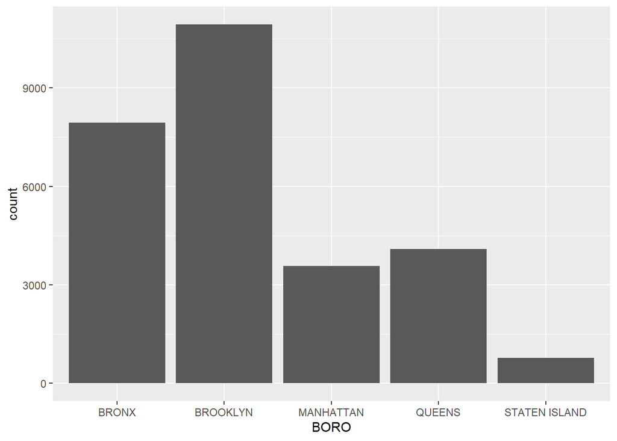

```r
# Create bar plots for each character variable
plot = ggplot(data=df)
plot + geom_bar(mapping=aes(x=BORO))
```

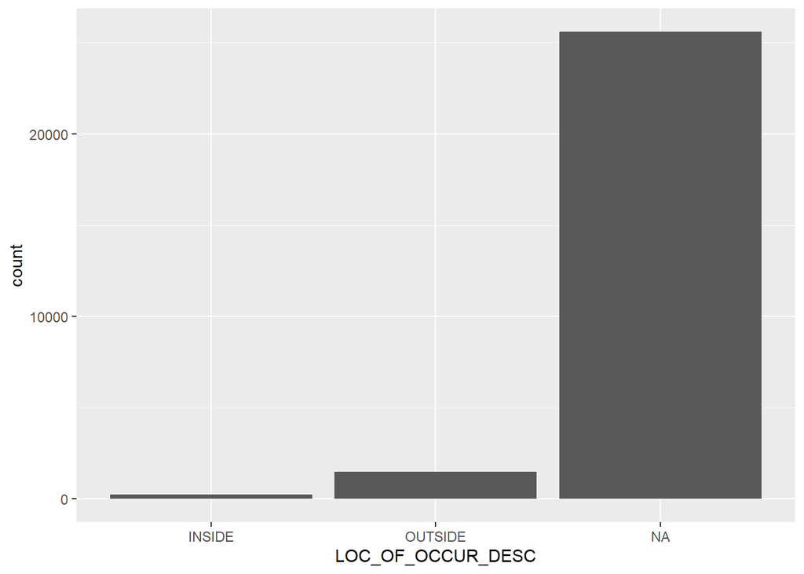

```r
plot + geom_bar(mapping=aes(x=LOC_OF_OCCUR_DESC))
```

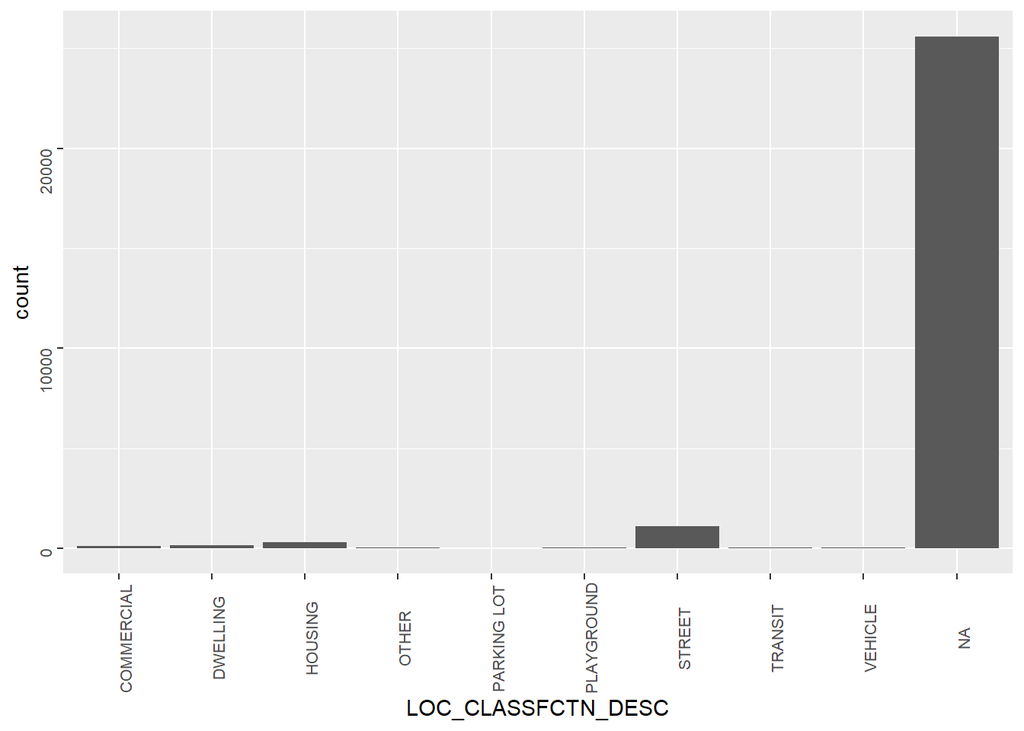

```r
plot + geom_bar(mapping=aes(x=LOC_CLASSFCTN_DESC))  + theme(axis.text= element_text(size=rel(0.7), angle=90))
```

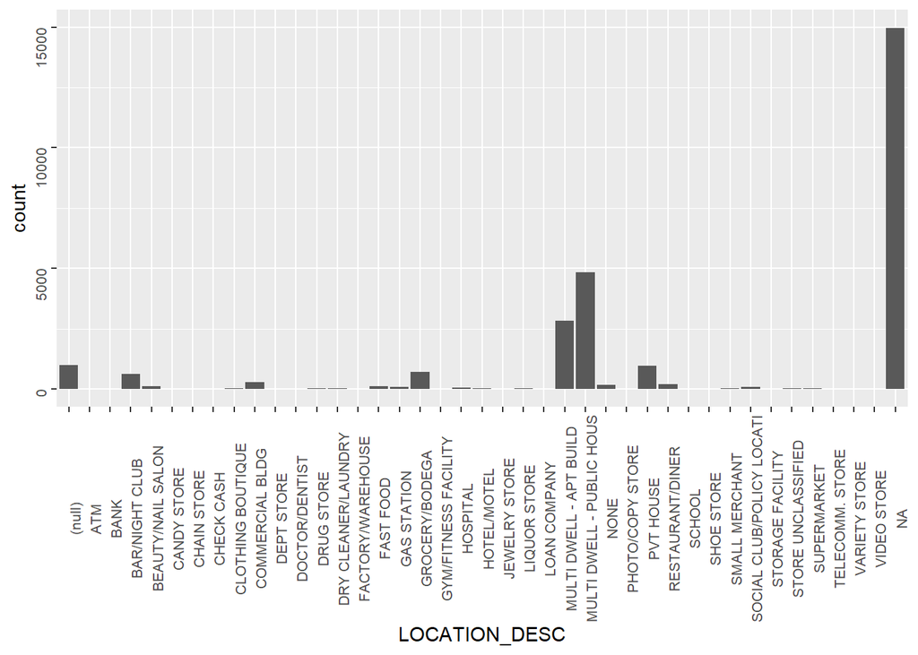

```r
plot + geom_bar(mapping=aes(x=LOCATION_DESC)) + theme(axis.text= element_text(size=rel(0.7), angle=90))
```

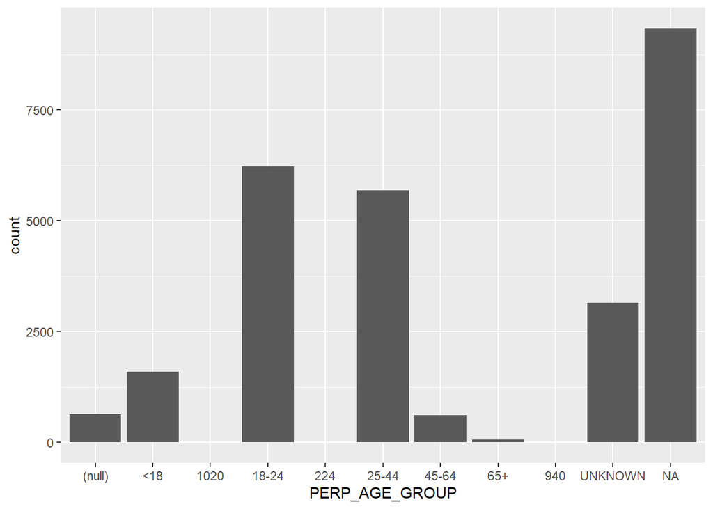

```r
plot + geom_bar(mapping=aes(x=PERP_AGE_GROUP))
```

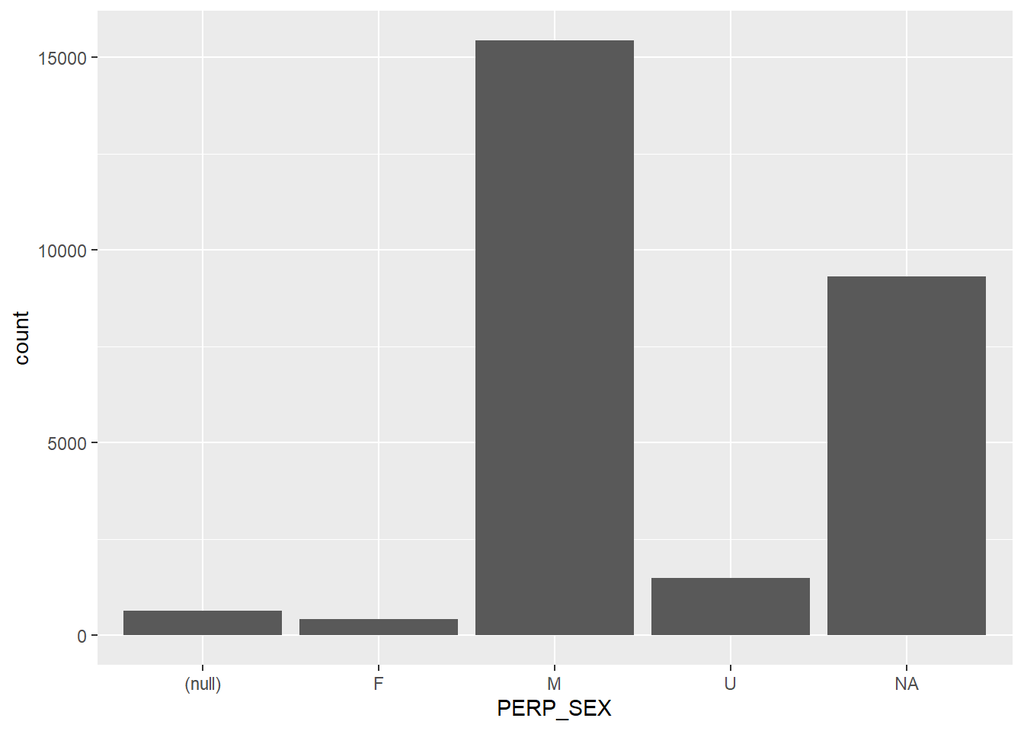

```r
plot + geom_bar(mapping=aes(x=PERP_SEX))
```

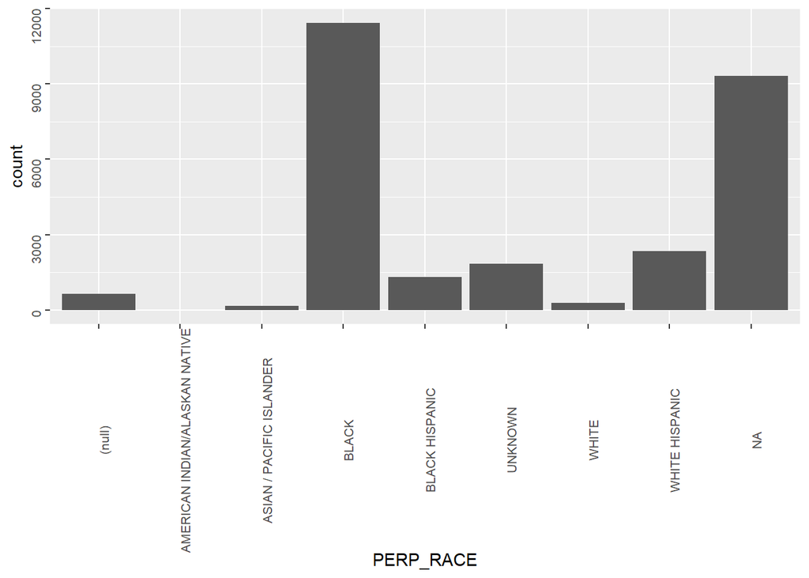

```r
plot + geom_bar(mapping=aes(x=PERP_RACE)) + theme(axis.text= element_text(size=rel(0.7), angle=90))
```

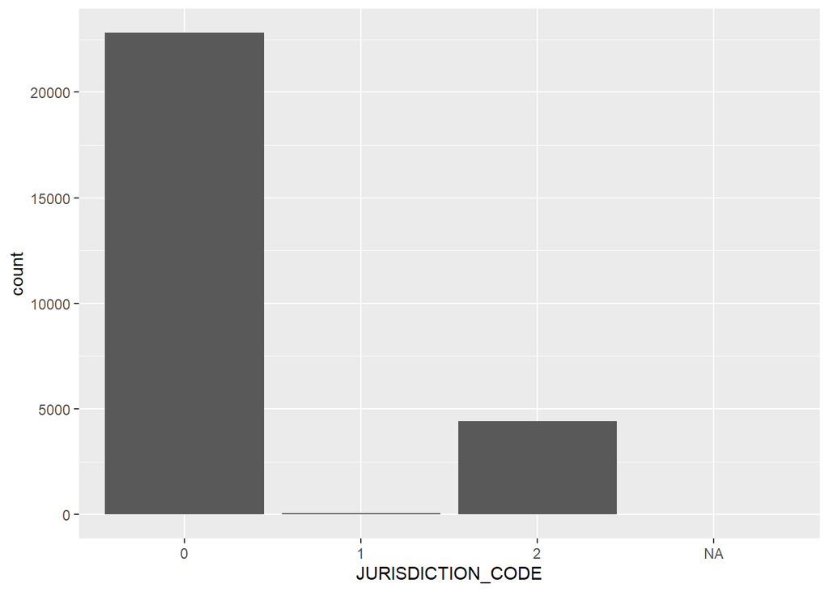

```r
plot + geom_bar(mapping=aes(x=JURISDICTION_CODE))
```

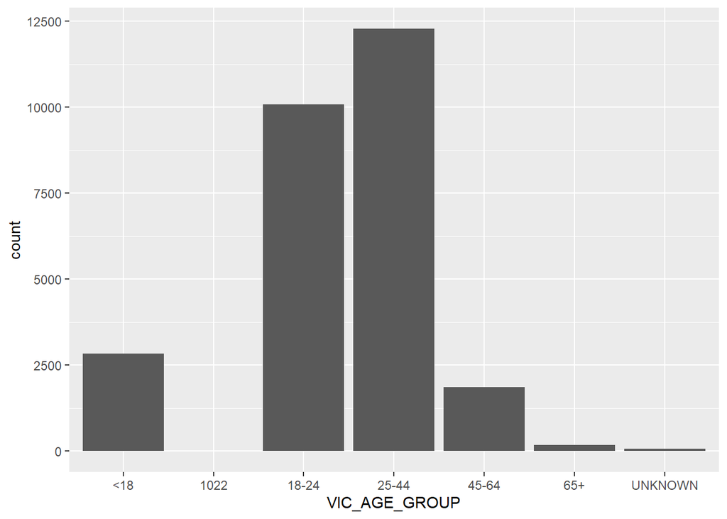

```r
plot + geom_bar(mapping=aes(x=VIC_AGE_GROUP))
```

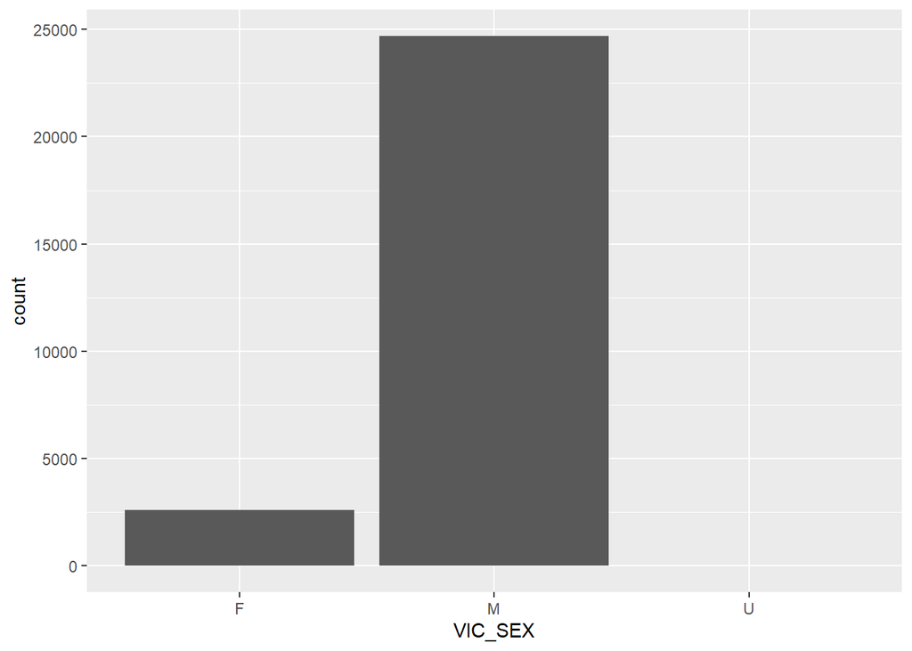

```r
plot + geom_bar(mapping=aes(x=VIC_SEX))
```

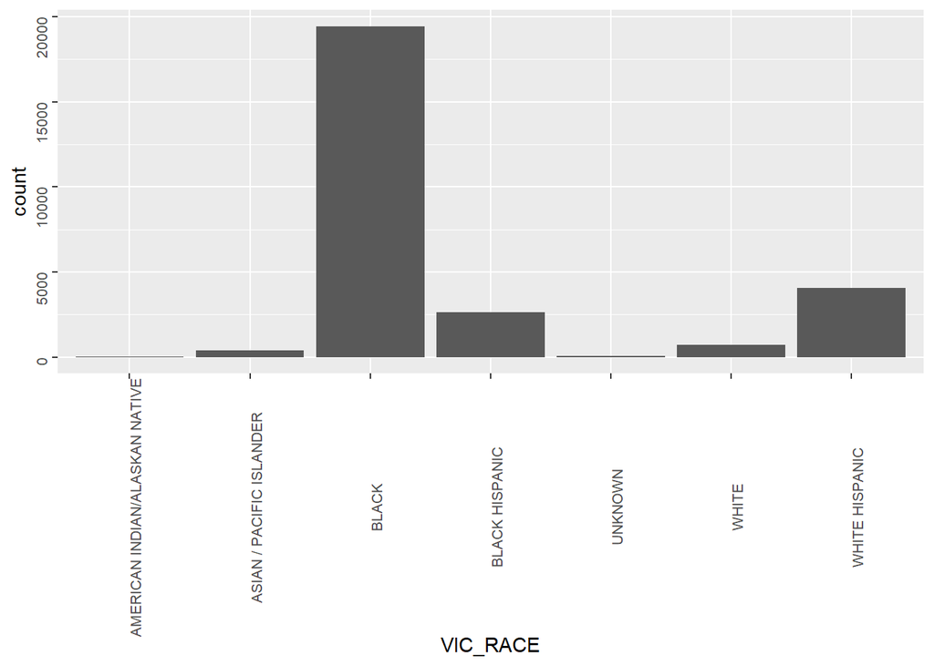

```r
plot + geom_bar(mapping=aes(x=VIC_RACE)) + theme(axis.text= element_text(size=rel(0.7), angle=90))
```

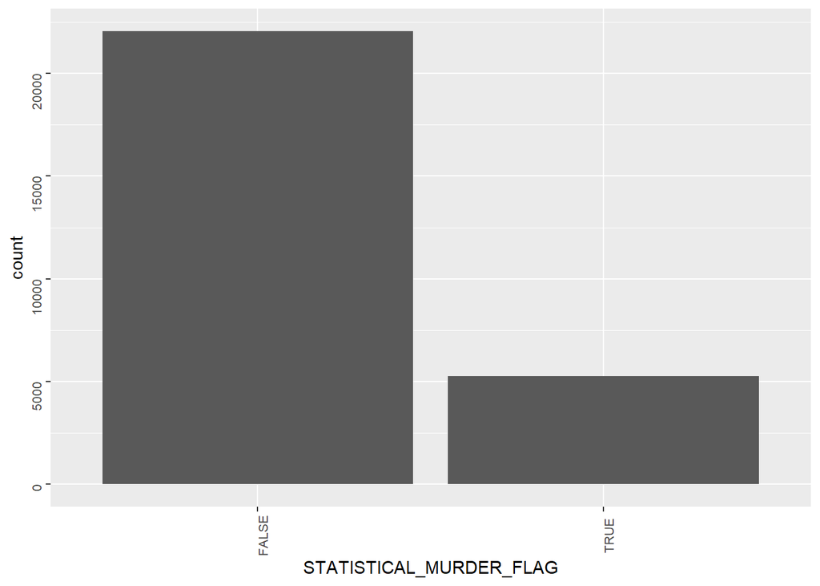

```r
plot + geom_bar(mapping=aes(x=STATISTICAL_MURDER_FLAG)) + theme(axis.text= element_text(size=rel(0.7), angle=90))
```

Now let’s fill in missing values for discrete variables.

For LOC_OF_OCCUR_DESC, LOC_CLASSFCTN_DESC, and LOCATION_DESC, since there are so many of them with missing values but only a few records has missing latitude and Longitude, I think the reason the data is missing is because it’s hard to fit them to any categories (instead of unknown location). I fill them with “OTHER”.

For PERP_AGE_GROUP, PERP_SEX, PERP_RACE, it seems it’s more reasonable to put them as “UNKOWN”.

For JURISDICTION_CODE, there are only two records have missing values. I just fill them with “UNKNOWN” as well.

```r
# Fill in missing values for discrete variables
df<-df%>%
  replace_na(list(LOC_OF_OCCUR_DESC="OTHER")) %>%
  replace_na(list(LOC_CLASSFCTN_DESC="OTHER")) %>%
  replace_na(list(LOCATION_DESC="OTHER")) %>%
  replace_na(list(PERP_AGE_GROUP="UNKNOWN")) %>%
  replace_na(list(PERP_SEX="U")) %>%
  replace_na(list(PERP_RACE="UNKNOWN")) %>%
  replace_na(list(JURISDICTION_CODE="UNKNOWN"))
```

Also, there are some typos in PERP_AGE_GROUP, and VIC_AGE_GROUP. I want to fix them.

```r
df$PERP_AGE_GROUP<-ifelse(df$PERP_AGE_GROUP=="1020"|df$PERP_AGE_GROUP=="224"|df$PERP_AGE_GROUP=="940","UNKNOWN",df$PERP_AGE_GROUP)
df$VIC_AGE_GROUP<-ifelse(df$VIC_AGE_GROUP=="1022","UNKNOWN",df$VIC_AGE_GROUP)
```

### For continuous variables

There are only 10 shootings missing latitude and Longitude. Let’s take a look.

```r
df%>%filter(is.na(Latitude)| is.na(Longitude))%>%
  select( INCIDENT_KEY, OCCUR_DATE, BORO,X_COORD_CD,Y_COORD_CD, everything() )
```

```
## # A tibble: 10 × 26
##    INCIDENT_KEY OCCUR_DATE BORO     X_COORD_CD Y_COORD_CD OCCUR_TIME YEAR  MONTH
##           <dbl> <date>     <chr>         <dbl>      <dbl> <time>     <fct> <fct>
##  1    250584475 2022-09-03 BROOKLYN     998002     196692 22:45      2022  Sept…
##  2    259091227 2022-12-19 BROOKLYN     990784     149362 23:23      2022  Dece…
##  3    251253188 2022-09-18 MANHATT…    1002173     249401 03:40      2022  Sept…
##  4    254053457 2022-11-13 QUEENS      1019164     210169 01:00      2022  Nove…
##  5    252281471 2022-10-09 BROOKLYN     995122     155693 19:15      2022  Octo…
##  6    251690448 2022-09-27 MANHATT…     997407     233806 23:30      2022  Sept…
##  7    251690448 2022-09-27 MANHATT…     997407     233806 23:30      2022  Sept…
##  8    255042633 2022-12-03 MANHATT…    1001891     245600 10:21      2022  Dece…
##  9    250460651 2022-09-01 QUEENS      1041717     197008 01:15      2022  Sept…
## 10    250340401 2022-08-30 BROOKLYN     988902     192641 00:10      2022  Augu…
## # ℹ 18 more variables: YEAR_MONTH <date>, DAY_OF_WEEK <fct>,
## #   LOC_OF_OCCUR_DESC <chr>, PRECINCT <dbl>, JURISDICTION_CODE <chr>,
## #   LOC_CLASSFCTN_DESC <chr>, LOCATION_DESC <chr>,
## #   STATISTICAL_MURDER_FLAG <lgl>, PERP_AGE_GROUP <chr>, PERP_SEX <chr>,
## #   PERP_RACE <chr>, VIC_AGE_GROUP <chr>, VIC_SEX <chr>, VIC_RACE <chr>,
## #   Latitude <dbl>, Longitude <dbl>, Lon_Lat <chr>,
## #   num_of_shooting_in_arrest <int>
```

Since they aren’t many, I will just exclude those 10 rows.

```r
# Exclude records with missing Latitude or Longitude
df<-df%>%filter(!is.na(Latitude) & !is.na(Longitude))

# Check if there are any missing values left
sum(is.na(df))
```

```
## [1] 0
```

```r
# Take a look at summary statistics
summary(df)
```

```
##   INCIDENT_KEY         OCCUR_DATE          OCCUR_TIME            YEAR
##  Min.   :  9953245   Min.   :2006-01-01   Length:27302      2006   : 2055
##  1st Qu.: 63859932   1st Qu.:2009-07-18   Class1:hms        2021   : 2011
##  Median : 90340495   Median :2013-04-27   Class2:difftime   2008   : 1959
##  Mean   :120812265   Mean   :2014-01-05   Mode  :numeric    2020   : 1948
##  3rd Qu.:188610564   3rd Qu.:2018-10-08                     2011   : 1939
##  Max.   :261190187   Max.   :2022-12-31                     2010   : 1912
##                                                             (Other):15478
##        MONTH         YEAR_MONTH            DAY_OF_WEEK       BORO
##  July     : 3238   Min.   :2006-01-01   Monday   :3882   Length:27302
##  August   : 3155   1st Qu.:2009-07-01   Tuesday  :3160   Class :character
##  June     : 2829   Median :2013-04-01   Wednesday:3000   Mode  :character
##  May      : 2571   Mean   :2013-12-21   Thursday :3033
##  September: 2567   3rd Qu.:2018-10-01   Friday   :3585
##  October  : 2278   Max.   :2022-12-01   Saturday :5193
##  (Other)  :10664                        Sunday   :5449
##  LOC_OF_OCCUR_DESC     PRECINCT      JURISDICTION_CODE  LOC_CLASSFCTN_DESC
##  Length:27302       Min.   :  1.00   Length:27302       Length:27302
##  Class :character   1st Qu.: 44.00   Class :character   Class :character
##  Mode  :character   Median : 68.00   Mode  :character   Mode  :character
##                     Mean   : 65.64
##                     3rd Qu.: 81.00
##                     Max.   :123.00
##
##  LOCATION_DESC      STATISTICAL_MURDER_FLAG PERP_AGE_GROUP
##  Length:27302       Mode :logical           Length:27302
##  Class :character   FALSE:22036             Class :character
##  Mode  :character   TRUE :5266              Mode  :character
##
##
##
##
##    PERP_SEX          PERP_RACE         VIC_AGE_GROUP        VIC_SEX
##  Length:27302       Length:27302       Length:27302       Length:27302
##  Class :character   Class :character   Class :character   Class :character
##  Mode  :character   Mode  :character   Mode  :character   Mode  :character
##
##
##
##
##    VIC_RACE           X_COORD_CD        Y_COORD_CD        Latitude
##  Length:27302       Min.   : 914928   Min.   :125757   Min.   :40.51
##  Class :character   1st Qu.:1000033   1st Qu.:182833   1st Qu.:40.67
##  Mode  :character   Median :1007742   Median :194478   Median :40.70
##                     Mean   :1009451   Mean   :208128   Mean   :40.74
##                     3rd Qu.:1016838   3rd Qu.:239518   3rd Qu.:40.82
##                     Max.   :1066815   Max.   :271128   Max.   :40.91
##
##    Longitude        Lon_Lat          num_of_shooting_in_arrest
##  Min.   :-74.25   Length:27302       Min.   : 1.00
##  1st Qu.:-73.94   Class :character   1st Qu.: 1.00
##  Median :-73.92   Mode  :character   Median : 1.00
##  Mean   :-73.91                      Mean   : 1.83
##  3rd Qu.:-73.88                      3rd Qu.: 2.00
##  Max.   :-73.70                      Max.   :18.00
##
```

## Analysis and insights

### Where are the most incidents?

First, I want to see shooting location distributions

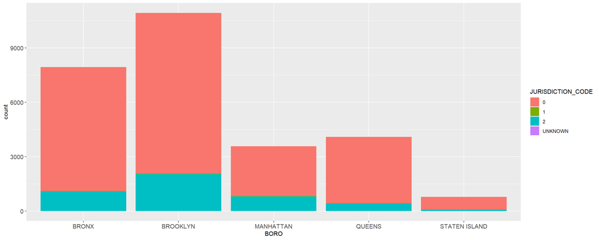

```r
plot = ggplot(data = df,mapping=aes(fill= JURISDICTION_CODE))
plot+geom_bar(mapping=aes(BORO)) + theme(axis.text=element_text(size=rel(1)))
```

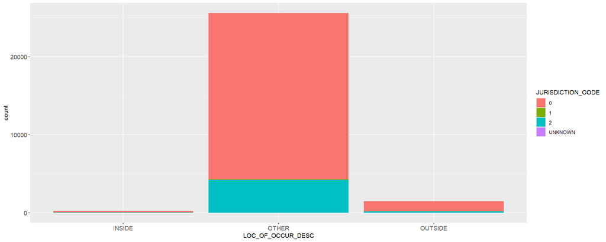

```r
plot+geom_bar(mapping=aes(LOC_OF_OCCUR_DESC)) + theme(axis.text=element_text(size=rel(1)))
```

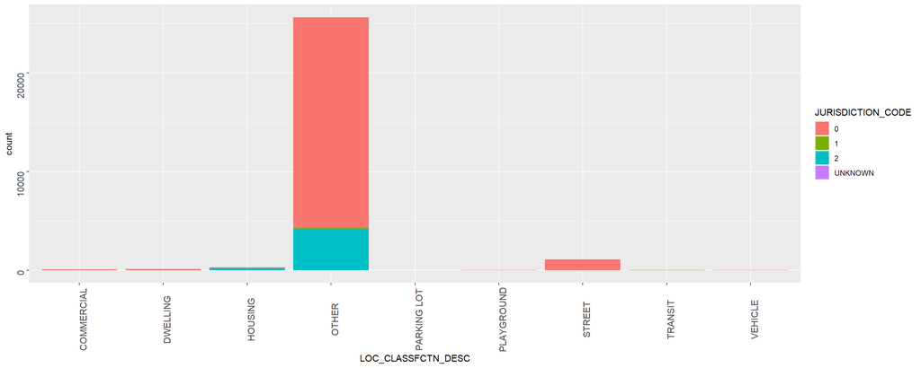

```r
plot+geom_bar(mapping=aes(LOC_CLASSFCTN_DESC)) + theme(axis.text=element_text(size=rel(1), angle=90))
```

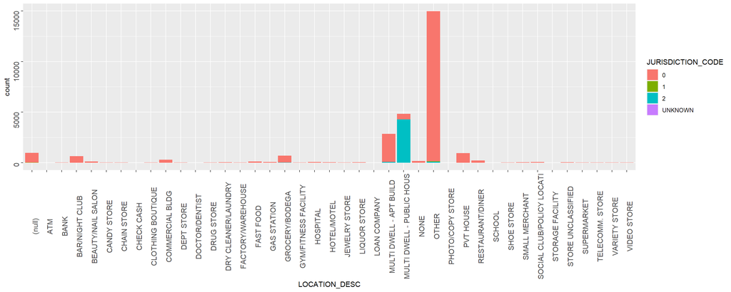

```r
plot+geom_bar(mapping=aes(LOCATION_DESC))  + theme(axis.text=element_text(size=rel(1), angle=90))
```

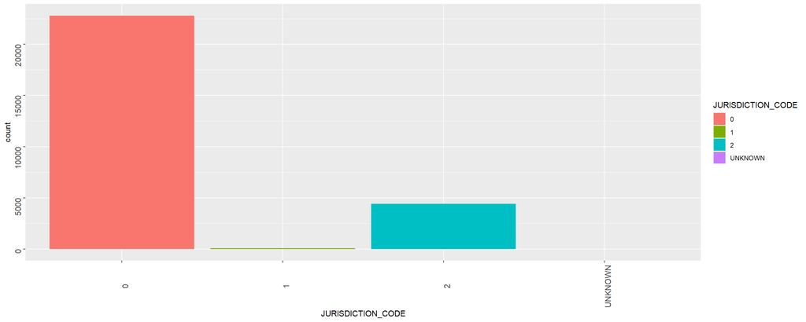

```r
plot+geom_bar(mapping=aes(JURISDICTION_CODE))  + theme(axis.text=element_text(size=rel(1), angle=90))
```

A map below with longitude and latitude can help us to see shooting distribution geographically better.

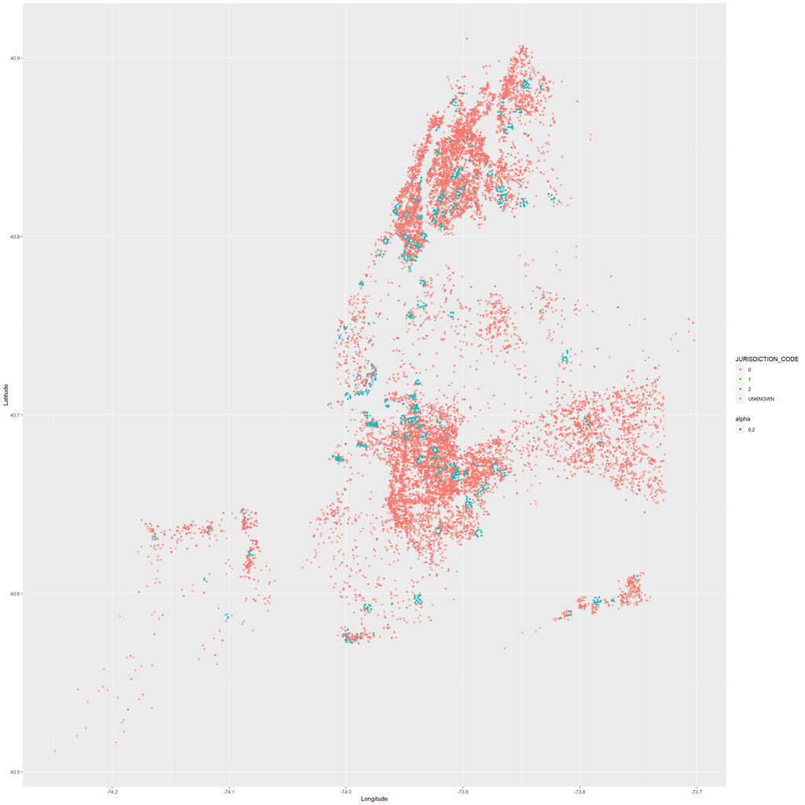

```r
plot = ggplot(data=df, mapping=aes(color= JURISDICTION_CODE,alpha=0.2))

plot+  geom_point(mapping=aes(x=Longitude, y=Latitude))
```

### Who are the shooters and victoms?

Next, let’s look at some shooter and victim distributions

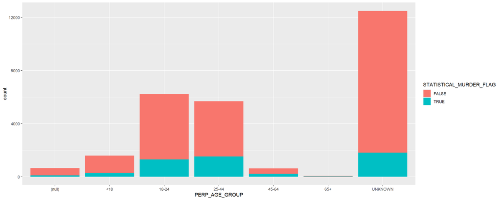

```r
ggplot_df = ggplot(data = df, mapping=aes(fill=STATISTICAL_MURDER_FLAG) )
ggplot_df + geom_bar(mapping=aes(x=PERP_AGE_GROUP))
```

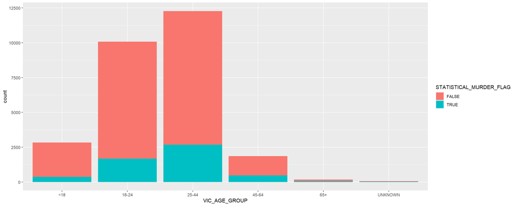

```r
ggplot_df + geom_bar(mapping=aes(x=VIC_AGE_GROUP))
```

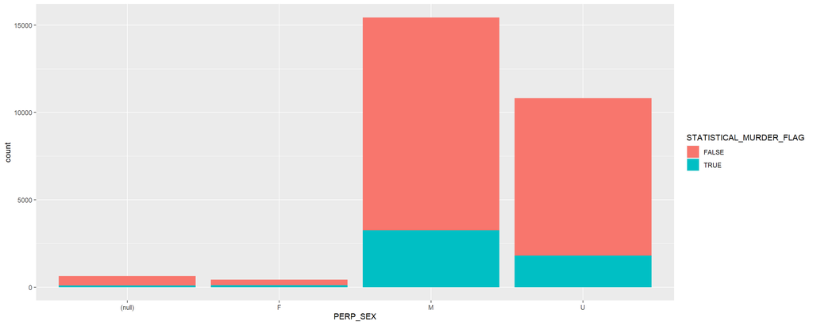

```r
ggplot_df + geom_bar(mapping=aes(x=PERP_SEX))
```

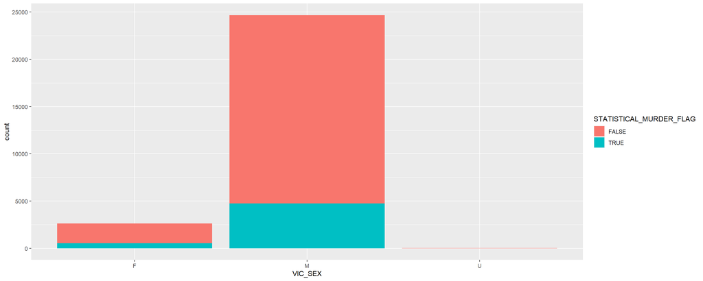

```r
ggplot_df + geom_bar(mapping=aes(x=VIC_SEX))
```

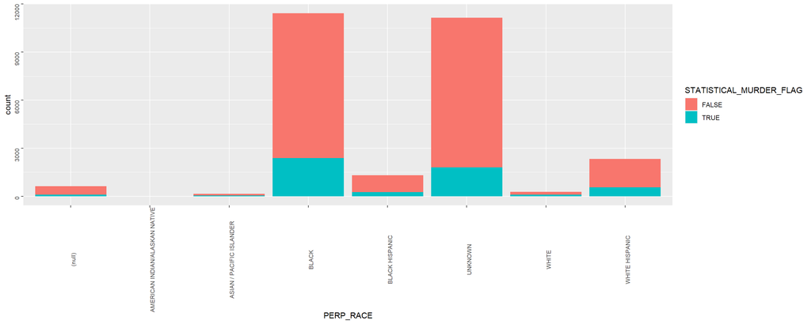

```r
ggplot_df + geom_bar(mapping=aes(x=PERP_RACE)) + theme(axis.text= element_text(size=rel(0.7),  angle=90))
```

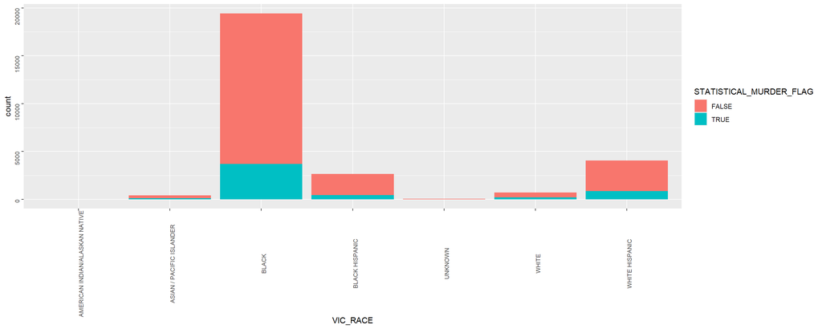

```r
ggplot_df + geom_bar(mapping=aes(x=VIC_RACE)) + theme(axis.text= element_text(size=rel(0.7), angle=90))
```

It seems most shooters are from 18-24 age groups, the next is 25-44. This makes me think if this can relate to the time of shootings as well. Because those young people might be more active at certain months, days of week, and times.

### When are the most incidents?

Lastly, let’s look at which year, month, day of week, time of day are the most incidents.

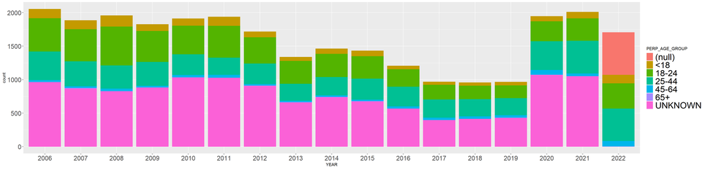

```r
ggplot_df = ggplot(data = df, mapping=aes(fill=PERP_AGE_GROUP) )

ggplot_df + geom_bar(mapping=aes(x=YEAR  ))  + theme(axis.text= element_text(size=rel(1.5)), legend.text= element_text(size=rel(2)) )
```

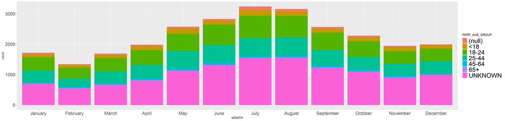

```r
ggplot_df + geom_bar(mapping=aes(x=MONTH ))   + theme(axis.text= element_text(size=rel(1.5)), legend.text= element_text(size=rel(2)) )
```

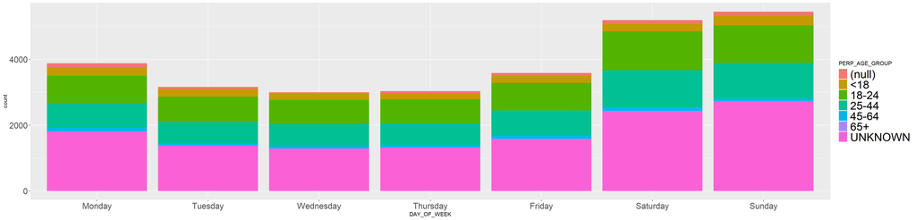

```r
ggplot_df + geom_bar(mapping=aes(x= DAY_OF_WEEK ))   + theme(axis.text= element_text(size=rel(1.5)), legend.text= element_text(size=rel(2)) )
```

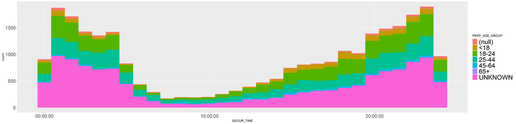

```r
ggplot_df + geom_histogram(mapping=aes(x=OCCUR_TIME ))   + theme(axis.text= element_text(size=rel(1.5)), legend.text= element_text(size=rel(2)) )
```

It seems shootings decreased in 2017 to 2019. But then after the Covid, shootings are almost doubled. Also, the % of age 25-44 shooters increased on and after 2020. I think that could because the job market were still recovering.

I can see Saturday and Sunday has the most shootings, and the most shooting occur after dinner time until next morning. I am not surprised to see this pattern. Unfortunately, this would require lots of police night and weekend shifts.

It’s interesting to see that the most shooting occur during the middle of the year (May to September) especially July to August. Maybe that’s because young people are more active during summer time? Maybe because of the summer breaks?

## Modeling data

Let’s just build a very simple linear regression and see how it does.

```r
# Aggregate shootings per year and month
df_agg<-df%>%group_by(YEAR,MONTH, YEAR_MONTH) %>%
         summarise(n=n()) %>%
         ungroup()
# Build an linear regression model
mod<-lm(n~MONTH+YEAR, data=df_agg)
summary(mod)
```

```
##
## Call:
## lm(formula = n ~ MONTH + YEAR, data = df_agg)
##
## Residuals:
##    Min     1Q Median     3Q    Max
## -76.15 -14.99  -0.15  11.71 106.03
##
## Coefficients:
##                Estimate Std. Error t value Pr(>|t|)
## (Intercept)     138.358      9.598  14.415  < 2e-16 ***
## MONTHFebruary   -22.118      8.886  -2.489 0.013738 *
## MONTHMarch       -1.647      8.886  -0.185 0.853165
## MONTHApril       15.706      8.886   1.767 0.078882 .
## MONTHMay         50.294      8.886   5.660 6.05e-08 ***
## MONTHJune        65.471      8.886   7.368 6.47e-12 ***
## MONTHJuly        89.529      8.886  10.075  < 2e-16 ***
## MONTHAugust      84.647      8.886   9.526  < 2e-16 ***
## MONTHSeptember   50.059      8.886   5.633 6.89e-08 ***
## MONTHOctober     33.059      8.886   3.720 0.000267 ***
## MONTHNovember    13.353      8.886   1.503 0.134712
## MONTHDecember    16.353      8.886   1.840 0.067409 .
## YEAR2007        -14.000     10.577  -1.324 0.187324
## YEAR2008         -8.000     10.577  -0.756 0.450425
## YEAR2009        -18.917     10.577  -1.789 0.075407 .
## YEAR2010        -11.917     10.577  -1.127 0.261399
## YEAR2011         -9.667     10.577  -0.914 0.361981
## YEAR2012        -28.167     10.577  -2.663 0.008460 **
## YEAR2013        -59.667     10.577  -5.641 6.62e-08 ***
## YEAR2014        -49.250     10.577  -4.657 6.31e-06 ***
## YEAR2015        -51.750     10.577  -4.893 2.23e-06 ***
## YEAR2016        -70.583     10.577  -6.674 3.13e-10 ***
## YEAR2017        -90.417     10.577  -8.549 5.84e-15 ***
## YEAR2018        -91.417     10.577  -8.643 3.27e-15 ***
## YEAR2019        -90.667     10.577  -8.572 5.05e-15 ***
## YEAR2020         -8.917     10.577  -0.843 0.400338
## YEAR2021         -3.667     10.577  -0.347 0.729246
## YEAR2022        -29.083     10.577  -2.750 0.006586 **
## ---
## Signif. codes:  0 '***' 0.001 '**' 0.01 '*' 0.05 '.' 0.1 ' ' 1
##
## Residual standard error: 25.91 on 176 degrees of freedom
## Multiple R-squared:  0.7886, Adjusted R-squared:  0.7562
## F-statistic: 24.32 on 27 and 176 DF,  p-value: < 2.2e-16
```

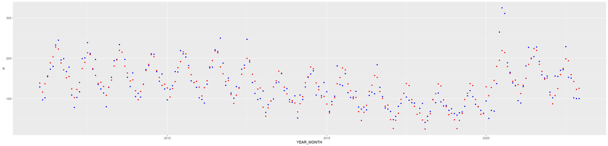

```r
df_with_pred<-df_agg%>%mutate(pred = predict(mod))

# Draw plots of actual values vs. predicted values
plot= ggplot(data = df_with_pred)
plot+
   geom_point(aes(x=YEAR_MONTH,y=n), color="blue")+
   geom_point(aes(x=YEAR_MONTH, y=pred), color="red")
```

## Bias

There are many sources of bias when we do data science projects.

For this project, I think the data is limited. There are only 21 variables and I don’t know how the data was collected. There are so many missing and null values. What are the causes of those missing values? How were data collected? For example, there are many shootings with null or missing LOC_OF_OCCUR_DESC. Do they mean the location unknown or cannot defined? Also, I can see shootings happen in the middle of year mostly but I didn’t check this for all years. This might not be true for some years.